# Discrete Bayes Filter Demo

Adapted by Michael Bloem  
from [Chapter 2: Discrete Bayes](https://nbviewer.jupyter.org/github/rlabbe/Kalman-and-Bayesian-Filters-in-Python/blob/master/02-Discrete-Bayes.ipynb)  
of [Kalman & Bayesian Filters in Python](https://nbviewer.jupyter.org/github/rlabbe/Kalman-and-Bayesian-Filters-in-Python/blob/master/table_of_contents.ipynb)  
by Roger Labbe

## Tracking a dog at work

[figure not shown]

## Sensors

Location sensor:

- Reports whether dog is in front of a door or wall
- Initially we'll assume it is perfect, but later analyze noisy sensor location sensor measurements

Movement sensor:

- Reports whether the dog is moving clockwise or counter-clockwise
- We'll assume this measurement is perfect throughout, but later analyze cases where the dog moves faster or slower than we assume

## Initial beliefs about dog location

- Equally likely to be anywhere
- 10 locations, so we'll assign an equal probability of $\frac{1}{10}$ to each
- In Bayesian statistics, this distribution is called the *prior*

```python
import numpy as np
belief = np.array([1./10]*10)
print(belief)
```

```
[0.1 0.1 0.1 0.1 0.1 0.1 0.1 0.1 0.1 0.1]
```

## Modeling the world (the hallway)

- As simple as recording which locations are doors and which are walls
- Use a length-10 vector
- 1 for doors
- 0 for walls

```python
hallway = np.array([1, 1, 0, 0, 0, 1, 0, 0, 0, 0])
```

## First location measurement

- First location measurement is **door**
- For now, assume sensor always returns correct answer
- Don't know which door, so assign an equal probability of $\frac{1}{3}$ to each

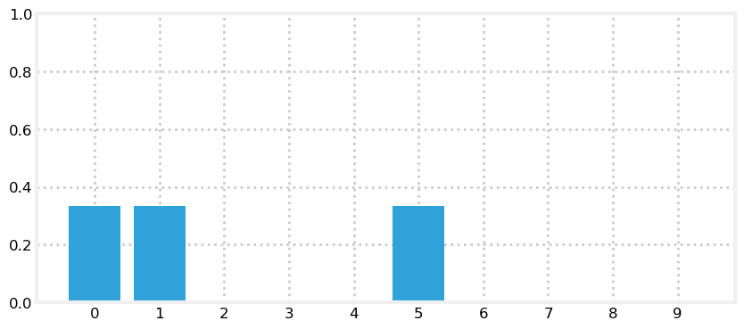

```python
belief = (1/3)*hallway
book_plots.bar_plot(belief)
```

## Noisy sensors

- Suppose now that our location sensor is noisy
- When we get a reading of **door** or **wall**, testing shows the sensors is 3x more likely to be right than wrong

```python
def update_belief(hall, belief, z, correct_scale):
    for i, val in enumerate(hall):
        if val == z:
            belief[i] *= correct_scale
```

```
belief: [0.3 0.3 0.1 0.1 0.1 0.3 0.1 0.1 0.1 0.1]
sum = 1.6000000000000005
```

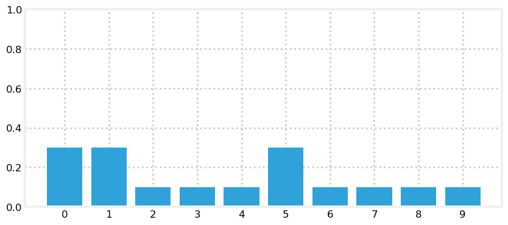

```python
belief = np.array([0.1] * 10)
reading = 1 # 1 is 'door'

update_belief(hallway, belief, z=reading, correct_scale=3.)

print('belief:', belief)
print('sum =', sum(belief))

plt.figure()
book_plots.bar_plot(belief)
```

## Normalizing

- Our updated belief did not sum to 1, so it is not a probability distribution.
- To overcome this, we "normalize"

```python
belief / sum(belief)
```

```
array([0.187, 0.187, 0.062, 0.062, 0.062, 0.187, 0.062, 0.062, 0.062,
       0.062])
```

## Refactoring

We can refactor our normalized `update_belief` code to be cleaner and more efficient, and also to show how it implements Bayes' rule.

Let's specify the probability of the sensor being correct, and compute the scale factor from that. The equation for that is

$$scale = \frac{prob_{correct}}{prob_{incorrect}} = \frac{prob_{correct}} {1-prob_{correct}}$$

We can replace the `for` loop with

```
belief[hall==z] *= scale
```

and only the elements which equal `z` will be multiplied by `scale`.

## More refactoring

FilterPy implements normalization with the `normalize` function:

```
from filterpy.discrete_bayes import normalize
normalize(belief)
```

## Now refactoring to show Bayes' rule

In Bayesian statistics, we call `belief` the **prior**: the probability distribution before including the latest measurement's information.

When we computed `belief[hall==z] *= scale`, we were computing how *likely* each position was given the measurement. The resulting **likelihood** is not a probability distribution because it does not sum to one.

The combination of these gives the Bayes' rule equation:

$$\mathtt{posterior} = \frac{\mathtt{likelihood} \times \mathtt{prior}}{\mathtt{normalization}}$$

```python
def scaled_update(hall, belief, z, z_prob):
    scale = z_prob / (1. - z_prob)
    likelihood = np.ones(len(hall))
    likelihood[hall==z] *= scale
    return normalize(likelihood * belief)
```

To be even more general, leave it up to the function caller to compute the likelihood, which will vary by application. Then we can have this highly general implementation (provided in `FilterPy`) to update the prior using Bayes' rule:

```
def update(likelihood, prior):
    return normalize(likelihood * prior)
```

Computing the likelihood in our application and then using the `update()` function looks like this:

```python
from filterpy.discrete_bayes import update

def lh_hallway(hall, z, z_prob):
    """ compute likelihood that a measurement matches
    positions in the hallway."""

    try:
        scale = z_prob / (1. - z_prob)
    except ZeroDivisionError:
        scale = 1e8

    likelihood = np.ones(len(hall))
    likelihood[hall==z] *= scale
    return likelihood

belief = np.array([0.1] * 10)
likelihood = lh_hallway(hallway, z=1, z_prob=.75)
update(likelihood, belief)
```

```
array([0.187, 0.187, 0.062, 0.062, 0.062, 0.187, 0.062, 0.062, 0.062,
       0.062])
```

## Recap: using location measurements to update our prior beliefs with Bayes' rule

We've shown how to update our beliefs about where the dog is located by using the (noisy) measurement from the location sensor.

We used Bayes' rule to perfrom this update.

What about the movement sensor and our system process model?

## Quick review of terminology and filtering steps

- **system**: what we are trying to model or filter
- **state**: system's current configuration or value  
  (filters produce an **estimated state**)
- **observation** or **measurement**: data describing the system’s state at a point in time
- **observation error** or **measurement error**: difference between the observed and actual state
- **system process model** or **system dynamics**: mathematical description of how the system state changes over time
- **system error** or **process error**: error in process model
- **(time) evolution** of the state or system: after some time has passed (usually a constant period like a second or day)
  1. use the process model to **predict** a new state estimate (the **prior**) without the benefit of new sensor measurements
  2. **update** the predicted state estimate with new measurements to get the **posterior** state estimate

```python
book_plots.predict_update_chart()
```

[output not shown]

## Incorporating Movement

First let's deal with the simple case---assume the movement sensor is perfect and our system model is perfect.

Suppose the movement sensor reports "clockwise" for and 1 time unit passes.

How would we alter our `belief` array?

We should shift all the belief values 1 space to the right.

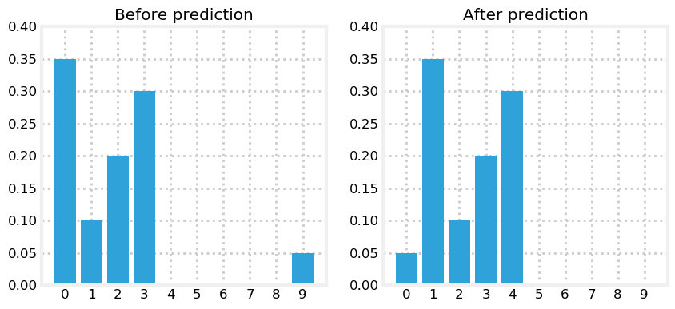

```python
def perfect_predict(belief, direction, time_steps):
    """ move the position by `time_steps` spaces
    in the direction indicated by direction
    (+1=clockwise and -1=counter-clockwise)
    """
    move = direction * time_steps
    n = len(belief)
    result = np.zeros(n)
    for i in range(n):
        result[i] = belief[(i-move) % n]
    return result

belief = np.array([.35, .1, .2, .3, 0, 0, 0, 0, 0, .05])
plt.subplot(121)
book_plots.bar_plot(belief, title='Before prediction', ylim=(0, .4))

belief = perfect_predict(belief, 1, 1)
plt.subplot(122)
book_plots.bar_plot(belief, title='After prediction', ylim=(0, .4))
```

## Adding uncertainty to predictions of the system model

`perfect_predict(belief, direction, time_steps)` assumes that the dog moves at a uniform number of locations per time step.

Let's consider that the model might be wrong because the dog might walk faster or slower (**not** because of errors in the direction sensor readings, which we still assume to be perfect).

When the sensor reports clockwise movement of some number of steps:

- it is 80% likely to be correct (i.e., the position actually moved the reported number of steps)
- it is 10% likely to overshoot one position clockwise (because the dog walked faster than the process model assumes)
- it is 10% likely to undershoot one position counter clockwise (because the dog walked slower than the process model assumes)

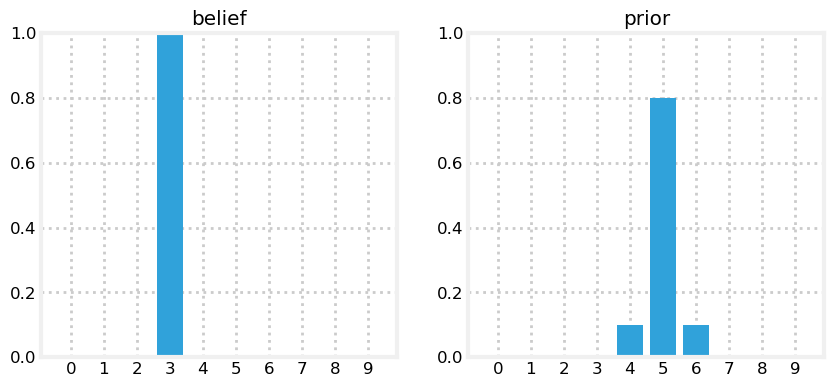

```python
def predict_move(belief, direction, time_steps, p_under, p_correct, p_over):
    move = direction * time_steps
    n = len(belief)
    prior = np.zeros(n)
    for i in range(n):
        prior[i] = (
            belief[(i-move) % n]   * p_correct +
            belief[(i-move-1) % n] * p_over +
            belief[(i-move+1) % n] * p_under)
    return prior

belief = [0., 0., 0., 1., 0., 0., 0., 0., 0., 0.]
prior = predict_move(belief, 1, 2, .1, .8, .1)
book_plots.plot_belief_vs_prior(belief, prior)
```

It appears to work correctly. Now what happens when our belief is not 100% certain?

```
array([0.  , 0.  , 0.  , 0.04, 0.38, 0.52, 0.06, 0.  , 0.  , 0.  ])
```

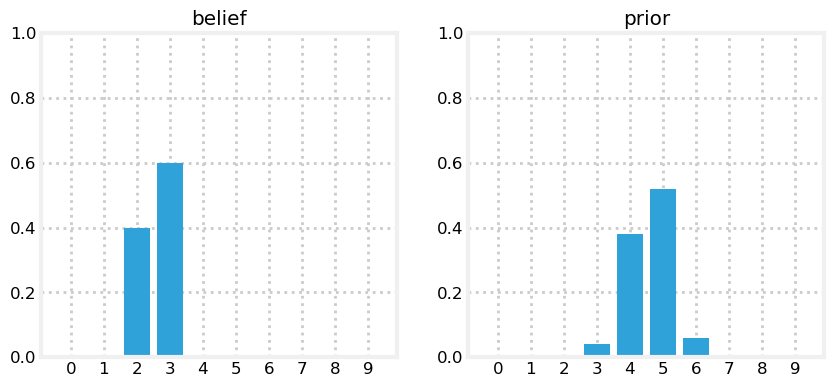

```python
belief = [0, 0, .4, .6, 0, 0, 0, 0, 0, 0]
prior = predict_move(belief, 1, 2, .1, .8, .1)
book_plots.plot_belief_vs_prior(belief, prior)
prior
```

## Effect of uncertain predictions after many time steps

What will happen if we keep predicting based on the (perfect) movement sensor and our uncertain predictions based on the system dynamics model and its system error?

```python
belief = np.array([1.0, 0, 0, 0, 0, 0, 0, 0, 0, 0])
beliefs = []
beliefs.append(belief)

for i in range(100):
    belief = predict_move(belief, 1, 1, .1, .8, .1)
    beliefs.append(belief)
```

[output not shown]

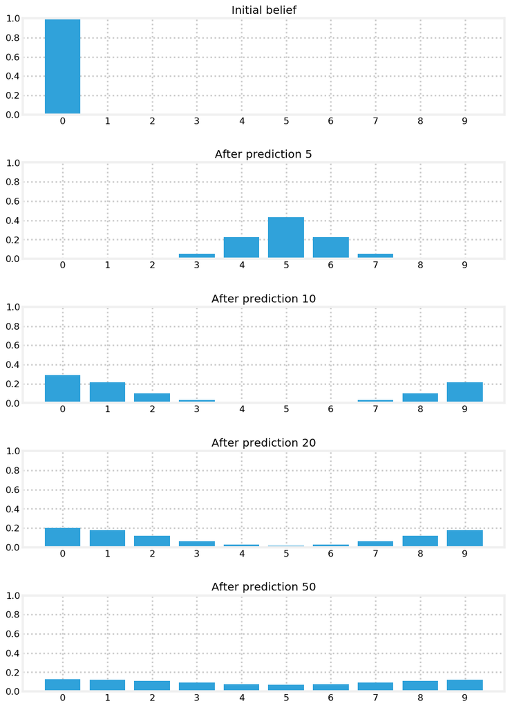

```python
fig, ax = plt.subplots(figsize=(10,15))
plt.subplot(511)
book_plots.bar_plot(beliefs[0], title='Initial belief', ylim=(0, 1))
plt.subplot(512)
book_plots.bar_plot(beliefs[5], title='After prediction 5', ylim=(0, 1))
plt.subplot(513)
book_plots.bar_plot(beliefs[10], title='After prediction 10', ylim=(0, 1))
plt.subplot(514)
book_plots.bar_plot(beliefs[20], title='After prediction 20', ylim=(0, 1))
plt.subplot(515)
book_plots.bar_plot(beliefs[50], title='After prediction 50', ylim=(0, 1))
```

```python
print('Initial Belief:', beliefs[0])
print('Final Belief:', belief)
```

```
Initial Belief: [1. 0. 0. 0. 0. 0. 0. 0. 0. 0.]
Final Belief: [0.104 0.103 0.101 0.099 0.097 0.096 0.097 0.099 0.101 0.103]
```

After 100 iterations, we have lost almost all information even though we started as 100% certain that the dog was in position 0 and we have a movement sensor that tells us which direction the dog is moving with no error.

Why did we become uncertain?

Because of our process error! The dog sometimes walks faster or slower than the assumed one location per time step, and over time this makes us uncertain about where he is located (if we get no location measurements).

## Recap: using movement measurements and system dynamics to predict a new prior belief for a new time step

We've shown how to predict the new prior beliefs about where the dog is located by using the (perfect) movement measurement and our system process model.

The system process model has a process error, so our predictions become less and less certain...

... unless we can incorporate new measurements as well.

## Integrating measurements and movement updates

- The problem of losing information during a prediction may make it seem as if our system would quickly devolve into having no knowledge.
- However, each prediction is followed by an update where we incorporate the measurement into the estimate (the predicted prior from the last prediction step). The update improves our knowledge.
- The output of the update step is fed into the next prediction. The prediction degrades our certainty.
- That is passed into another update, where certainty is again increased.

We've already programmed the prediction and update steps - we just need to string them together to build this Discrete Bayes Filter!

```python
book_plots.predict_update_chart()
```

[output not shown]

```python
from filterpy.discrete_bayes import update

hallway = np.array([1, 1, 0, 0, 0, 0, 0, 0, 1, 0])
prior = np.array([.1] * 10)
likelihood = lh_hallway(hallway, z=1, z_prob=.75)
posterior = update(likelihood, prior)
book_plots.plot_prior_vs_posterior(prior, posterior, ylim=(0,.5))
```

[output not shown]

```python
kernel = (.1, .8, .1)
prior = predict(posterior, 1, kernel)
book_plots.plot_prior_vs_posterior(prior, posterior, True, ylim=(0,.5))
```

[output not shown]

```python
likelihood = lh_hallway(hallway, z=1, z_prob=.75)
posterior = update(likelihood, prior)
book_plots.plot_prior_vs_posterior(prior, posterior, ylim=(0,.5))
```

[output not shown]

```python
prior = predict(posterior, 1, kernel)
likelihood = lh_hallway(hallway, z=0, z_prob=.75)
posterior = update(likelihood, prior)
book_plots.plot_prior_vs_posterior(prior, posterior, ylim=(0,.5))
```

[output not shown]

```python
prior = predict(posterior, 1, kernel)
likelihood = lh_hallway(hallway, z=0, z_prob=.75)
posterior = update(likelihood, prior)
book_plots.plot_prior_vs_posterior(prior, posterior, ylim=(0,.5))
```

[output not shown]

## The Discrete Bayes Algorithm

This chart illustrates the algorithm:

```python
book_plots.predict_update_chart()
```

[output not shown]

This filter is a form of the g-h filter. Here we are using the percentages for the errors to implicitly compute the $g$ and $h$ parameters. We could express the discrete Bayes algorithm as a g-h filter, but that would obscure the logic of this filter.

The filter equations are:

$$\begin{aligned} \bar {\mathbf x} &= \mathbf x \ast f_{\mathbf x}(\bullet)\, \, &\text{Predict Step} \\ \mathbf x &= \|\mathcal L \cdot \bar{\mathbf x}\|\, \, &\text{Update Step}\end{aligned}$$

$\mathcal L$ is the usual way to write the likelihood function, so I use that. The $\|\|$ notation denotes taking the norm. We need to normalize the product of the likelihood with the prior to ensure $x$ is a probability distribution that sums to one.

We can express this in pseudocode.

**Initialization**

```
1. Initialize our belief in the state
```

**Predict**

```
1. Based on the system behavior, predict state for the next time step
2. Adjust belief to account for the uncertainty in prediction
```

**Update**

```
1. Get a measurement and associated belief about its accuracy
2. Compute how likely it is the measurement matches each state
3. Update state belief with this likelihood
```

When we cover the Kalman filter we will use this exact same algorithm; only the details of the computation will differ.

Algorithms in this form are sometimes called *predictor correctors*. We make a prediction, then correct them.

Let's animate this. First Let's write functions to perform the filtering and to plot the results at any step. I've plotted the position of the doorways in black. Prior are drawn in orange, and the posterior in blue. I draw a thick vertical line to indicate where Simon really is. This is not an output of the filter - we know where Simon is only because we are simulating his movement.

```python
def discrete_bayes_sim(prior, kernel, measurements, z_prob, hallway):
    posterior = np.array([.1]*10)
    priors, posteriors = [], []
    for i, z in enumerate(measurements):
        prior = predict(posterior, 1, kernel)
        priors.append(prior)

        likelihood = lh_hallway(hallway, z, z_prob)
        posterior = update(likelihood, prior)
        posteriors.append(posterior)
    return priors, posteriors


def plot_posterior(posteriors, i):
    plt.title('Posterior')
    book_plots.bar_plot(hallway, c='k')
    book_plots.bar_plot(posteriors[i], ylim=(0, 1.0))
    plt.axvline(i % len(hallway), lw=5)

def plot_prior(priors, i):
    plt.title('Prior')
    book_plots.bar_plot(hallway, c='k')
    book_plots.bar_plot(priors[i], ylim=(0, 1.0), c='#ff8015')
    plt.axvline(i % len(hallway), lw=5)

def animate_discrete_bayes(step):
    step -= 1
    i = step // 2
    if step % 2 == 0:
        plot_prior(priors, i)
    else:
        plot_posterior(posteriors, i)
```

Let's run the filter and animate it.

```python
# change these numbers to alter the simulation
kernel = (.1, .8, .1)
z_prob = 1.0
hallway = np.array([1, 1, 0, 0, 0, 0, 0, 0, 1, 0])

# measurements with no noise
zs = [hallway[i % len(hallway)] for i in range(50)]

priors, posteriors = discrete_bayes_sim(prior, kernel, zs, z_prob, hallway)
interact(animate_discrete_bayes, step=IntSlider(value=1, max=len(zs)*2));
```

Another thing to note is how accurate our estimate becomes when we are in front of a door, and how it degrades when in the middle of the hallway. This should make intuitive sense. There are only a few doorways, so when the sensor tells us we are in front of a door this boosts our certainty in our position. A long stretch of no doors reduces our certainty.

## The Effect of Bad Sensor Data

You may be suspicious of the results above because I always passed correct sensor data into the functions. However, we are claiming that this code implements a *filter* - it should filter out bad sensor measurements. Does it do that?

To make this easy to program and visualize I will change the layout of the hallway to mostly alternating doors and hallways, and run the algorithm on 6 correct measurements:

```python
hallway = np.array([1, 0, 1, 0, 0]*2)
kernel = (.1, .8, .1)
prior = np.array([.1] * 10)
zs = [1, 0, 1, 0, 0, 1]
z_prob = 0.75
priors, posteriors = discrete_bayes_sim(prior, kernel, zs, z_prob, hallway)
interact(animate_discrete_bayes, step=IntSlider(value=12, max=len(zs)*2));
```

We have identified the likely cases of having started at position 0 or 5, because we saw this sequence of doors and walls: 1,0,1,0,0. Now I inject a bad measurement. The next measurement should be 0, but instead we get a 1:

```python
measurements = [1, 0, 1, 0, 0, 1, 1]
priors, posteriors = discrete_bayes_sim(prior, kernel, measurements, z_prob, hallway);
plot_posterior(posteriors, 6)
```

[output not shown]

```python
with figsize(y=5.5):
    measurements = [1, 0, 1, 0, 0, 1, 1, 1, 0, 0]
    for i, m in enumerate(measurements):
        likelihood = lh_hallway(hallway, z=m, z_prob=.75)
        posterior = update(likelihood, prior)
        prior = predict(posterior, 1, kernel)
        plt.subplot(5, 2, i+1)
        book_plots.bar_plot(posterior, ylim=(0, .4), title='step {}'.format(i+1))
    plt.tight_layout()
```

[output not shown]

## Drawbacks and Limitations

Do not be mislead by the simplicity of the examples I chose. This is a robust and complete filter, and you may use the code in real world solutions. If you need a multimodal, discrete filter, this filter works.

With that said, this filter it is not used often because it has several limitations. Getting around those limitations is the motivation behind the chapters in the rest of this book.

The first problem is scaling. Our dog tracking problem used only one variable, $pos$, to denote the dog's position. Most interesting problems will want to track several things in a large space. Realistically, at a minimum we would want to track our dog's $(x,y)$ coordinate, and probably his velocity $(\dot{x},\dot{y})$ as well. We have not covered the multidimensional case, but instead of an array we use a multidimensional grid to store the probabilities at each discrete location. Each `update()` and `predict()` step requires updating all values in the grid, so a simple four variable problem would require $O(n^4)$ running time *per time step*. Realistic filters can have 10 or more variables to track, leading to exorbitant computation requirements.

The second problem is that the filter is discrete, but we live in a continuous world. The histogram requires that you model the output of your filter as a set of discrete points. A 100 meter hallway requires 10,000 positions to model the hallway to 1cm accuracy. So each update and predict operation would entail performing calculations for 10,000 different probabilities. It gets exponentially worse as we add dimensions. A 100x100 m$^2$ courtyard requires 100,000,000 bins to get 1cm accuracy.

A third problem is that the filter is multimodal. In the last example we ended up with strong beliefs that the dog was in position 4 or 9. This is not always a problem. Particle filters, which we will study later, are multimodal and are often used because of this property. But imagine if the GPS in your car reported to you that it is 40% sure that you are on D street, and 30% sure you are on Willow Avenue.

A forth problem is that it requires a measurement of the change in state. We need a motion sensor to detect how much the dog moves. There are ways to work around this problem, but it would complicate the exposition of this chapter, so, given the aforementioned problems, I will not discuss it further.

With that said, if I had a small problem that this technique could handle I would choose to use it; it is trivial to implement, debug, and understand, all virtues.

## Tracking and Control

We have been passively tracking an autonomously moving object. But consider this very similar problem. I am automating a warehouse and want to use robots to collect all of the items for a customer's order. Perhaps the easiest way to do this is to have the robots travel on a train track. I want to be able to send the robot a destination and have it go there. But train tracks and robot motors are imperfect. Wheel slippage and imperfect motors means that the robot is unlikely to travel to exactly the position you command. There is more than one robot, and we need to know where they all are so we do not cause them to crash.

So we add sensors. Perhaps we mount magnets on the track every few feet, and use a Hall sensor to count how many magnets are passed. If we count 10 magnets then the robot should be at the 10th magnet. Of course it is possible to either miss a magnet or to count it twice, so we have to accommodate some degree of error. We can use the code from the previous section to track our robot since magnet counting is very similar to doorway sensing.

But we are not done. We've learned to never throw information away. If you have information you should use it to improve your estimate. What information are we leaving out? We know what control inputs we are feeding to the wheels of the robot at each moment in time. For example, let's say that once a second we send a movement command to the robot - move left 1 unit, move right 1 unit, or stand still. If I send the command 'move left 1 unit' I expect that in one second from now the robot will be 1 unit to the left of where it is now. This is a simplification because I am not taking acceleration into account, but I am not trying to teach control theory. Wheels and motors are imperfect. The robot might end up 0.9 units away, or maybe 1.2 units.

Now the entire solution is clear. We assumed that the dog kept moving in whatever direction he was previously moving. That is a dubious assumption for my dog! Robots are far more predictable. Instead of making a dubious prediction based on assumption of behavior we will feed in the command that we sent to the robot! In other words, when we call `predict()` we will pass in the commanded movement that we gave the robot along with a kernel that describes the likelihood of that movement.

### Simulating the Train Behavior

We need to simulate an imperfect train. When we command it to move it will sometimes make a small mistake, and its sensor will sometimes return the incorrect value.

```python
class Train(object):

    def __init__(self, track_len, kernel=[1.], sensor_accuracy=.9):
        self.track_len = track_len
        self.pos = 0
        self.kernel = kernel
        self.sensor_accuracy = sensor_accuracy

    def move(self, distance=1):
        """ move in the specified direction
        with some small chance of error"""

        self.pos += distance
        # insert random movement error according to kernel
        r = random.random()
        s = 0
        offset = -(len(self.kernel) - 1) / 2
        for k in self.kernel:
            s += k
            if r <= s:
                break
            offset += 1
        self.pos = int((self.pos + offset) % self.track_len)
        return self.pos

    def sense(self):
        pos = self.pos
         # insert random sensor error
        if random.random() > self.sensor_accuracy:
            if random.random() > 0.5:
                pos += 1
            else:
                pos -= 1
        return pos
```

With that we are ready to write the filter. We will put it in a function so that we can run it with different assumptions. I will assume that the robot always starts at the beginning of the track. The track is implemented as being 10 units long, but think of it as a track of length, say 10,000, with the magnet pattern repeated every 10 units. A length of 10 makes it easier to plot and inspect.

```python
def train_filter(iterations, kernel, sensor_accuracy,
             move_distance, do_print=True):
    track = np.array([0, 1, 2, 3, 4, 5, 6, 7, 8, 9])
    prior = np.array([.9] + [0.01]*9)
    posterior = prior[:]
    normalize(prior)

    robot = Train(len(track), kernel, sensor_accuracy)
    for i in range(iterations):
        # move the robot and
        robot.move(distance=move_distance)

        # peform prediction
        prior = predict(posterior, move_distance, kernel)

        #  and update the filter
        m = robot.sense()
        likelihood = lh_hallway(track, m, sensor_accuracy)
        posterior = update(likelihood, prior)
        index = np.argmax(posterior)

        if do_print:
            print('''time {}: pos {}, sensed {}, '''
                  '''at position {}'''.format(
                    i, robot.pos, m, track[robot.pos]))

            print('''        estimated position is {}'''
                  ''' with confidence {:.4f}%:'''.format(
                  index, posterior[index]*100))

    book_plots.bar_plot(posterior)
    if do_print:
        print()
        print('final position is', robot.pos)
        index = np.argmax(posterior)
        print('''Estimated position is {} with '''
              '''confidence {:.4f}%:'''.format(
                index, posterior[index]*100))
```

Read the code and make sure you understand it. Now let's do a run with no sensor or movement error. If the code is correct it should be able to locate the robot with no error. The output is a bit tedious to read, but if you are at all unsure of how the update/predict cycle works make sure you read through it carefully to solidify your understanding.

```python
import random

random.seed(3)
np.set_printoptions(precision=2, suppress=True, linewidth=60)
train_filter(4, kernel=[1.], sensor_accuracy=.999,
             move_distance=4, do_print=True)
```

[output not shown]

```python
random.seed(5)
train_filter(4, kernel=[.1, .8, .1], sensor_accuracy=.9,
         move_distance=4, do_print=True)
```

[output not shown]

Now let's run a very long simulation and see how the filter responds to errors.

```python
with figsize(y=5.5):
    for i in range (4):
        random.seed(3)
        plt.subplot(221+i)
        train_filter(148+i, kernel=[.1, .8, .1],
                     sensor_accuracy=.8,
                     move_distance=4, do_print=False)
        plt.title ('iteration {}'.format(148+i))
```

[output not shown]

## Bayes Theorem and the Total Probability Theorem

We developed the math in this chapter merely by reasoning about the information we have at each moment. In the process we discovered [*Bayes' Theorem*](https://en.wikipedia.org/wiki/Bayes%27_theorem) and the [*Total Probability Theorem*](https://en.wikipedia.org/wiki/Law_of_total_probability).

Bayes theorem tells us how to compute the probability of an event given previous information.

We implemented the `update()` function with this probability calculation:

$$ \mathtt{posterior} = \frac{\mathtt{likelihood}\times \mathtt{prior}}{\mathtt{normalization\, factor}}$$

We haven't developed the mathematics to discuss Bayes yet, but this is Bayes' theorem. Every filter in this book is an expression of Bayes' theorem. In the next chapter we will develop the mathematics, but in many ways that obscures the simple idea expressed in this equation:

$$ updated\,knowledge = \big\|likelihood\,of\,new\,knowledge\times prior\, knowledge \big\|$$

where $\| \cdot\|$ expresses normalizing the term.

We came to this with simple reasoning about a dog walking down a hallway. Yet, as we will see the same equation applies to a universe of filtering problems. We will use this equation in every subsequent chapter.

Likewise, the `predict()` step computes the total probability of multiple possible events. This is known as the *Total Probability Theorem* in statistics, and we will also cover this in the next chapter after developing some supporting math.

For now I need you to understand that Bayes' theorem is a formula to incorporate new information into existing information.

## Summary

The code is very short, but the result is impressive! We have implemented a form of a Bayesian filter. We have learned how to start with no information and derive information from noisy sensors. Even though the sensors in this chapter are very noisy (most sensors are more than 80% accurate, for example) we quickly converge on the most likely position for our dog. We have learned how the predict step always degrades our knowledge, but the addition of another measurement, even when it might have noise in it, improves our knowledge, allowing us to converge on the most likely result.

This book is mostly about the Kalman filter. The math it uses is different, but the logic is exactly the same as used in this chapter. It uses Bayesian reasoning to form estimates from a combination of measurements and process models.

**If you can understand this chapter you will be able to understand and implement Kalman filters.** I cannot stress this enough. If anything is murky, go back and reread this chapter and play with the code. The rest of this book will build on the algorithms that we use here. If you don't understand why this filter works you will have little success with the rest of the material. However, if you grasp the fundamental insight - multiplying probabilities when we measure, and shifting probabilities when we update leads to a converging solution - then after learning a bit of math you are ready to implement a Kalman filter.

## References

- [1] D. Fox, W. Burgard, and S. Thrun. "Monte carlo localization: Efficient position estimation for mobile robots." In *Journal of Artifical Intelligence Research*, 1999.

  http://www.cs.cmu.edu/afs/cs/project/jair/pub/volume11/fox99a-html/jair-localize.html
- [2] Dieter Fox, et. al. "Bayesian Filters for Location Estimation". In *IEEE Pervasive Computing*, September 2003.

  http://swarmlab.unimaas.nl/wp-content/uploads/2012/07/fox2003bayesian.pdf
- [3] Sebastian Thrun. "Artificial Intelligence for Robotics".

  https://www.udacity.com/course/cs373
- [4] Khan Acadamy. "Introduction to the Convolution"

  https://www.khanacademy.org/math/differential-equations/laplace-transform/convolution-integral/v/introduction-to-the-convolution
- [5] Wikipedia. "Convolution"

  http://en.wikipedia.org/wiki/Convolution
- [6] Wikipedia. "Law of total probability"

  http://en.wikipedia.org/wiki/Law_of_total_probability
- [7] Wikipedia. "Time Evolution"

  https://en.wikipedia.org/wiki/Time_evolution
- [8] We need to rethink how we teach statistics from the ground up

  http://www.statslife.org.uk/opinion/2405-we-need-to-rethink-how-we-teach-statistics-from-the-ground-up